# Lesson 5 - Plot all the things! From Data Exploration to Publication-Quality Figures

### A Note on Colour Palettes

There are 3 main types of colour palettes.

1. *Sequential* - implies an order to your data - ie. light to dark implies low values to high values.

```r
p <- ggplot(dat[dat$Taxa %in% keep$Taxa,] , aes(x = Taxa, y = OTUs, fill = Taxa)) +
  geom_boxplot(outlier.colour = "red") +
  scale_y_log10() +
  facet_grid(~Country, labeller = labeller(Country = labels)) +
  ggtitle("Abundance of Taxa by Country") +
  xlab(NULL) +
  ylab("log(OTUs)") +
  guides(fill=FALSE) +
  theme(axis.text.x = element_text(angle=90, hjust=1))
```

[output not shown]

2. *Diverging* - low and high values are extremes, and the middle values are important - still goes from light to dark, but 3 colours mainly used.

[figure not shown]

3. *Qualitative* - there is no quantitative relationship between colours. This is usually used for categorical data.

[figure not shown]

Which of these types is `ggplot2`’s default color palette?

Let’s test one of the `RColorBrewer` palettes out on our data.

[figure not shown]

Many colour palettes now exist. I’ll showcase a couple that work nicely with `ggplot2`. These packages also have colorblind friendly options. `RColorBrewer` has options for these 3 types of palettes, which you can see with `display.brewer.all()`. With a smaller dataset, we could make a call in `ggplot` directly to `scale_fill_brewer()`, which just requires a choice of one of `RColorBrewer`’s palettes, such as “Spectral”. However, we have 24 Taxa and these palettes have 8-12 colours, so we have to get creative.

I have simply taken the 2 qualitative palettes that each have a length of 12, put them into one palette, and made sure my values were unique. This can then be passed to `ggplot` via `scale_fill_manual()`.

[figure not shown]

You can always choose a vector of your own colors using this ‘R color cheatsheet’ (https://www.nceas.ucsb.edu/~frazier/RSpatialGuides/colorPaletteCheatsheet.pdf).

Names of colours as well as colour codes are accepted.

`scale_fill_manual(values=c("purple", "cornflowerblue", "grey", "yellow", "orange", "FF0000"))`

The `viridis` package also has some nice color palettes (https://cran.r-project.org/web/packages/viridis/vignettes/intro-to-viridis.html). I think they might all be diverging palettes (qualitative is best for our Taxa), but I will showcase a couple here.

[figure not shown]

`RSkittleBrewer` is another option for funky colour palettes. `ggsci` has a variety of color palettes inspired by different scientific journals as well as television shows (https://cran.r-project.org/web/packages/ggsci/vignettes/ggsci.html).

### Theme: Attributes Unrelated to Your Data

As mentioned earlier, it is possible to customize every single aspect of a `ggplot`. Most of this occurs with a call to `theme()`, which you can think of as modifying everything BUT your data. For example, my axis labels can be modified, but they (hopefully) have something to do with my data. However, changing the size of the text or the font of the labels is unrelated to my data, and the same structure (text font & size) could be carried over to other plots if I saved my own theme.

Things that you can change with `theme()` include the axis, legend, panels, gridlines, or background.

Each *element* of a theme inherits from one of:

- element_text (text elements like font, colour, size, face (bold, italics), alignment),
- element_line (grid lines, axis lines),
- element_rect (panels and backgrounds - colour, size, fill),
- element_blank (assigns nothing, usually when you are trying to get rid of something),
- element_grob (making a grid grob).

`ggplot2` comes with some themes - I suggest starting with the one that is close to what you want, and start modifying from there.

Check out these *themes*:

- theme_minimal()
- theme_classic()
- theme_bw()
- theme_void()
- theme_dark()
- theme_gray()
- theme_light()

You can look at the default for each theme simply by typing it into the console.

[figure not shown]

And this is what `theme_bw()` practically looks like:

```r
theme_bw
```

```
function (base_size = 11, base_family = "", base_line_size = base_size/22,
    base_rect_size = base_size/22)
{
    theme_grey(base_size = base_size, base_family = base_family,
        base_line_size = base_line_size, base_rect_size = base_rect_size) %+replace%
        theme(panel.background = element_rect(fill = "white",
            colour = NA), panel.border = element_rect(fill = NA,
            colour = "grey20"), panel.grid = element_line(colour = "grey92"),
            panel.grid.minor = element_line(size = rel(0.5)),
            strip.background = element_rect(fill = "grey85",
                colour = "grey20"), legend.key = element_rect(fill = "white",
                colour = NA), complete = TRUE)
}
<environment: namespace:ggplot2>
```

```r
p + theme_bw() + theme(panel.border = element_blank())
```

[output not shown]

`ggthemes` is a package of themes. Some of these themes are based off of graphs seen in print or on websites (the economist, wall street journal, fivethirtyeight) or to match standard tools (excel, google docs). Information about these themes can be found at https://github.com/jrnold/ggthemes.

Here are 2 possible themes.

[figure not shown]

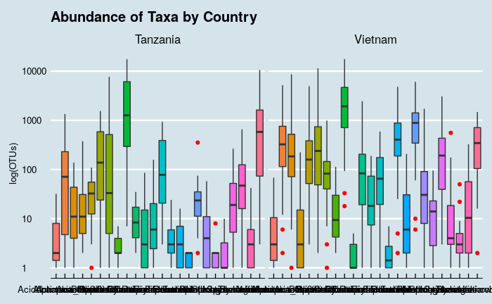

You can also make your own custom theme as demoed here: http://joeystanley.com/blog/custom-themes-in-ggplot2

I am going to show you how to customize a plot, starting from `theme_minimal()` because I don’t like the grey backgrounds or harsh axis lines.

[figure not shown]

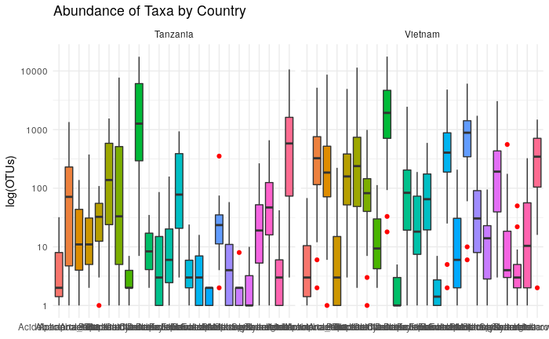

It isn’t necessary to remember all of this syntax, I frequently find myself back at the help page at http://ggplot2.tidyverse.org/reference/theme.html.

As mentioned the last call to `theme()` will override previous calls that conflict. Therefore, if we want to start with `theme_minimal()` as our base, it has to be in our code BEFORE the other modifications.

```r
p +
  theme_minimal() +
  theme(axis.text.x = element_text(angle = 90, hjust = 1),
        panel.border = element_rect(fill=NA),
        strip.text.x = element_text(face = "bold", size = 16),
        plot.title = element_text(hjust=0.5, size = 18),
        axis.ticks.y = element_line())
```

[output not shown]

**Challenge**

Change the colour of the plot background. Add minor gridlines, and make the major gridlines black.

### Saving your Figures

Up until now, we have taken for granted that our plots have been displayed using a *Graphic Device*.

#### Graphics Devices

```
Plots must be created on a graphics device.

The default graphics device is almost always the screen device, which is most useful for exploratory analysis.

File devices are useful for creating plots that can be included in other documents or sent to other people.

For file devices, there are vector (pdf, svg, postscript) and bitmap (png, jpeg, tiff) formats.

Vector formats are good for line drawings and plots with solid colors using a modest number of points.

Bitmap formats are good for plots with a large number of points, natural scenes or web-based plots.
```

(https://rdpeng.github.io/Biostat776/notes/pdf/grdevices.pdf)

`ggplot2` has its own function for saving its graphics: `ggsave()`. This allows us to skip the step of explicitly calling separate graphics devices and shutting them down afterwards (if you have saved plots in base R or `lattice`, this will sound familiar to you).

You can send the plot object to the screen device to preview your image, and then save that image by specifying the file device. If you do not specify the device type, `ggsave()` will guess it from your filename extension (pdf, jpeg, tiff, bmp, svg or png). Note that this will save whatever graphic was last on your screen device.

With `ggsave()` you can minimally input the filename you would like to have, and the path to your file.

```r
p+theme_minimal()+
  theme(axis.text.x = element_text(angle = 90, hjust = 1),
        panel.border = element_rect(fill = NA),
        strip.text.x = element_text(face = "bold", size = 16),
        plot.title = element_text(hjust=0.5, size = 18),
        axis.ticks.y = element_line(),
        panel.grid.major = element_line(),
        panel.grid.minor = element_line(),
        plot.background = element_rect(color = "cornflowerblue"))
```

[output not shown]

```r
ggsave("crazy_blue_graph.png", path = "img")
```

No image is sent to the screen device when a file is saved in this manner.

## Taking it up a notch

There are many fantastic R packages to analyze and visualize your data. As a group, we are likely working in a variety of specialized areas. The plots we have made so far today should be useful for data exploration for many different kinds of data. In the next section we are going to preview some more complex visualization types, but since these take more time to go through and not everyone may be interested in interactive graphics, network diagrams, time-series analysis, or geospatial data, we will not be plotting all of these together. We will, however learn how to arrange multiple plots per page, and also how to make an upset plot. If you are interested in a tutorial on one of these other visualization types, please indicate that in the comments area of the lesson survey (https://www.surveymonkey.com/r/H3PFQR3).

### Multiple plots on one page (ie. for publication images)

There are a variety of methods to mix multiple graphs on the same page, however `ggplot2` does not work well with all of them. I am going to work with a package based that uses `gridExtra`(which allows us to arrange plots) but works well with `ggplot2` called `ggpubr` (which allows us to align the axes of our plots). For a demonstration, we are going to take 3 plots that we made earlier (a boxplot, a histogram, and a dot plot), save them as objects, and then arrange and align them in the same figure. (http://www.sthda.com/english/rpkgs/ggpubr/)

While our grid areas are the same size, our plot backgrounds are not. Let’s adjust the legend so that it is in the top right corner of the plot, and remove the white background. We do not need the alpha legend. Do you remember how to get rid of it?

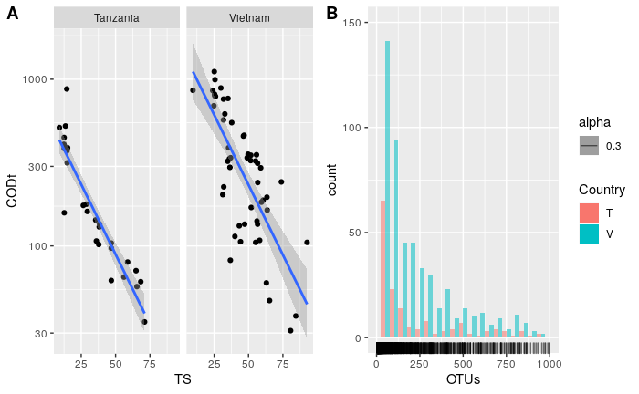

[figure not shown]

If y-axis lines or x-axis lines are not aligned, but this can be fixed with a call to `align = "v"` or `align="h"`.

To make sure all axis titles are the same size (B and C look a little off to me), we can specify using `font()` which text we want changed and the size we want to change it to. I am also going to make the legend title size the same.Let’s look at the `font()` function.

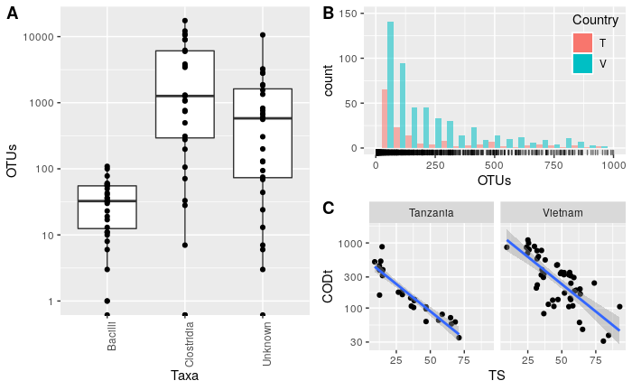

**Challenge**

Using the code available here for a density plot we made earlier in the lesson, make a combined figure. Imagine a square with 4 boxes. We are going to put our density plot in the top right and left boxes, the histogram in the bottom left box, and the box plot in the bottom right box. Make sure the legend and axis titles are the same size. Change the legend text for the line graph to be smaller than the legend title.

```
dens <- ggplot(fdat, aes(x=OTUs, fill=Country, alpha=0.3)) +
    geom_density() +
  geom_rug() +
  xlim(0, 1000)
```

### Upset Plots

**Packages**

UpSetR: https://github.com/hms-dbmi/UpSetR

Upset plots are an alternative to venn diagrams that show the intersection of sets, as well as the size of the sets. Additionally, venn diagrams can be difficult to interpret for greater than 2 or 3 sets. This is a real life figure from BMC Bioinformatics. Sure it looks pretty, but what does the number 24 represent in this picture in terms of A, B, C, D, and E?

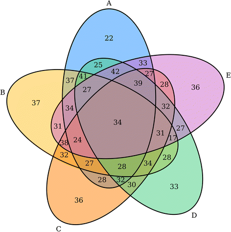

Let’s see how UpSet plots work practically.

*Question: For 8 Taxa, how many sites are each Taxa present at and what is the overlap between sites with other Taxa?*

I have picked 8 different Taxa, which would make a crazy venn diagram with a lot of zeros in it since a couple of these Taxa are rare.

[figure not shown]

The data that we have is an OTU table. For this purpose we simply want to know whether a given Taxa was present or absent in the sample, and then we can form intersections based on this information. So, for each OTU value that is *not* 0, we replace it with a 1 instead.

Then to use the `upset()` plotting function, we enter our data set, the number of sets we are inputting, if we want to order the results (in this case by frequency), and how many intersections we want to show. Here, I will show 15 intersections - we know the remaining intersections would be zero since this is ordered by frequency.

```r
#this is a tidyr way of transposing our data frame so that Taxa are in columns and sites are in rows
#this format is for the upset plot only, we can do the value replacement in either format
subtax  <- subtax %>%
   gather(sample, otus, -Taxa) %>%
   spread(Taxa, otus)
```

[output not shown]

### Interactive graphics

**Packages**

Plotly: https://plot.ly/r/

ggvis: http://ggvis.rstudio.com/interactivity.html

Heatmaps: https://github.com/talgalili/heatmaply

Interactive time-series data: https://rstudio.github.io/dygraphs/

### Network diagrams

**Packages**

visNetwork (based on igraph): https://datastorm-open.github.io/visNetwork/edges.html

### Circos Plots

**Packages**

Migest: https://gjabel.wordpress.com/category/r/migest/

### Geospatial Data

**Packages**

Static Maps: - https://bhaskarvk.github.io/user2017.geodataviz/notebooks/02-Static-Maps.nb.html

Interactive Maps: - https://bhaskarvk.github.io/user2017.geodataviz/notebooks/03-Interactive-Maps.nb.html

### Phylogenetics Data

**Packages**

ggtree: - http://www.bioconductor.org/packages/3.7/bioc/vignettes/ggtree/inst/doc/treeAnnotation.html#annotate-clades

treeman: - https://bmcresnotes.biomedcentral.com/articles/10.1186/s13104-016-2340-8

metacoder: - https://github.com/grunwaldlab/metacoder

phyloseq: - https://joey711.github.io/phyloseq/index.html

### Genomics Data

**Packages**

ggbio: - http://www.bioconductor.org/packages/2.11/bioc/vignettes/ggbio/inst/doc/ggbio.pdf

GenVisR: - https://bioconductor.org/packages/release/bioc/vignettes/GenVisR/inst/doc/Intro.html

GenomeGraphs: - https://bmcbioinformatics.biomedcentral.com/articles/10.1186/1471-2105-10-2

**Challenge**

Install and load the gapminder package. Save the gapminder data into an object using `dat <- gapminder`. Plot the following:

```
1. a qualitative variable with a quantitative variable (at least 2 ways).
  + Facet your plot by the qualitative variable.
2. two quantitative variables (at least 2 ways).
  + Add a regression line to your plot.
```

**Resources:**

Wickham, Hadley. (2010). A Layered Grammar of Graphics. Journal of Computational and Statistical Graphics.  
Wilkinson, L. (2005), The Grammar of Graphics (2nd ed.). Statistics and Computing, New York: Springer. [14, 18]  
Tufte, Edward R. The Visual Display of Quantitative Information.

http://www.cookbook-r.com/Graphs/  
https://github.com/jennybc/ggplot2-tutorial  
http://stcorp.nl/R_course/tutorial_ggplot2.html  
http://ggplot2.tidyverse.org/reference/theme.html  
http://joeystanley.com/blog/custom-themes-in-ggplot2  
https://github.com/jrnold/ggthemes  
https://www.nceas.ucsb.edu/~frazier/RSpatialGuides/colorPaletteCheatsheet.pdf  
https://cran.r-project.org/web/packages/ggrepel/vignettes/ggrepel.html  
http://www.cookbook-r.com/Graphs/Legends_(ggplot2)/  
https://github.com/eclarke/ggbeeswarm  
https://cran.r-project.org/web/packages/ggsci/vignettes/ggsci.html  
http://www.sthda.com/english/rpkgs/ggpubr/  
https://rpubs.com/drsong/9575  
http://elpub.bib.uni-wuppertal.de/edocs/dokumente/fbb/wirtschaftswissenschaft/sdp/sdp15/sdp15006.pdf  
http://www.sthda.com/english/articles/24-ggpubr-publication-ready-plots/81-ggplot2-easy-way-to-mix-multiple-graphs-on-the-same-page/  
https://rdpeng.github.io/Biostat776/notes/pdf/grdevices.pdf

# Post-Lesson Assessment

Your feedback is essential to help the next cohort of trainees. Please take a minute to complete the following short survey: https://www.surveymonkey.com/r/H3PFQR3

Thanks for coming!!!


# Appendix

### Circular Plots

```r
ggplot(dat, aes(x="", y=Country, fill = Country)) +
    geom_bar(stat = "identity", width = 1) +
  coord_polar(theta = "y")
```

### Lines

To draw a line graph, we select `geom_line()`.

```r
ggplot(ndat, aes(x=Temp, y=pH)) + geom_line()
```

```r
ggplot(ndat, aes(x=Temp, y=pH, colour = Country)) + geom_line()
```

#### Error bars

To plot error bars, we need to give the geom, `geom_errorbar()`, and the interval over which we want to draw the bar. This interval is usually one standard deviation, one standard error or a confidence interval.

Luckily, we have learned how to calculate the mean and standard deviation with `dplyr`. Once we have that, all we need to do is add or subtract the standard deviation from our data points to get the bounds of the error bar.

`geom_errorbar()` takes these bounds passed to the parameters ymax and ymin. In this case, since there were no sample replicates the standard deviation is taken from the mean of all of the soil readings in a given country at a given depth.

```r
errdat <- ndat %>% group_by(Country, Depth) %>% mutate(mean_pH = mean(pH)) %>% mutate(sd_pH= sd(pH))

ggplot(errdat, aes(x=Temp, y=pH, colour = Country)) +
  geom_line() +
  geom_errorbar(aes(ymin=pH-sd_pH, ymax = pH+sd_pH), width = 0.2, alpha = 0.4)
```

### Stripplots

The first plots we made we scatterplots with 2 continuous variables. With one discrete variable and one categorical variable, we can make a stripplot. We use the point geom for both of these types of plots.

```r
ggplot(dat, aes(x = Depth, y = OTUs)) + geom_point()
```

Again, we have a lot of values crushed near the x-axis. If we add log scaling to the y-axis, we get an error that this transformation created infinite values. This is because we have zeros in our data set.

```r
ggplot(dat, aes(x = Depth, y = OTUs)) +
  geom_point() +
  scale_y_log10()
```

Knowing this, we could ignore the warning, or add +1 to each OTU (negligable on a log scale).

```r
ggplot(dat, aes(x = Depth, y = OTUs+1)) +
  geom_point() +
  scale_y_log10()
```

In order to see the points a little better, we can ‘jitter’ them. Jittering spreads out our data points while keeping them in the same area of the plot so we can get an idea of density.

```r
ggplot(dat, aes(x = Depth, y = OTUs+1)) +
  geom_point(position = "jitter") +
  scale_y_log10() +
  facet_wrap(~Country)
```

### Bubble Plots

With bubble plots, we need to provide the size of our bubbles in a way that is proportional to our data, and provide a scale to map these to.

Let’s group our OTUs by Country and Taxa and look at the Taxa for the top 30 OTUs. As a refresher, try to do this using `dplyr` functions.

We are going to make our bubbles (which can be thought of as large points) with `geom_jitter()` so that our bubbles don’t overlap. Remember that we want to specify what we are plotting with **aesthetics**. We want the bubbles representing OTUs_per_Taxa, so we divide each value by pi when calling size.

```r
bdat <- dat %>%
  group_by(Taxa, Country) %>%
  mutate(OTUs_per_Taxa = sum(OTUs)) %>%
  arrange(desc(OTUs_per_Taxa)) %>%
  select(Taxa, Country, OTUs_per_Taxa) %>%
  unique() %>%
  .[1:30,]

ggplot(bdat, aes(x = Country, y = OTUs_per_Taxa, fill=Taxa)) +
  scale_y_log10() +
  geom_jitter(aes(size = OTUs_per_Taxa/pi), pch = 21, show.legend = TRUE)  +
  guides(fill = FALSE)
```

However, it is hard to tell proportionally how different these sizes are. Mapping values to a scale gives us more of an idea of their relative sizes. This is done by giving a range of values to `scale_size_continuous()`. This range is the size you want your plotting symbols (bubbles) to be after transformation. You can use trial and error to see what range you like; it is not changing your data, but rather your perception of the data.

```r
ggplot(bdat, aes(x = Country, y = OTUs_per_Taxa, fill=Taxa)) +
  scale_y_log10() +
  geom_jitter(aes(size = OTUs_per_Taxa/pi), pch = 21, show.legend = FALSE) +
  scale_size_continuous(range=c(1,30)) +
  guides(fill=FALSE)
```

#### Labelling Data Points

`ggplot2` provides 2 methods of labelling: `geom_label()` and `geom_text()`. Let’s look at the help menu to find out what the difference between them is.

We have to specify with **aesthetics** what we are plotting for our label.

```r
ggplot(bdat, aes(x = Country, y = OTUs_per_Taxa, fill=Taxa)) +
  scale_y_log10() +
  geom_jitter(aes(size = OTUs_per_Taxa/pi), pch = 21, show.legend = FALSE) +
  scale_size_continuous(range=c(1,30)) +
  geom_label(aes(label = Taxa), show.legend = FALSE)
```

This isn’t fantastic because our labels are overlapping. What parameters might you be able to use to move the labels? Try using them to get the labels to not overlap.

The text geom has an option to check for overlap of labels. `geom_text()` does not provide a background for the label, and it may be harder to tell which label belongs to each data point.

```r
ggplot(bdat, aes(x = Country, y = OTUs_per_Taxa, fill=Taxa)) +
  scale_y_log10() +
  geom_jitter(aes(size = sqrt(OTUs_per_Taxa/pi)), pch = 21, show.legend = FALSE) +
  scale_size_continuous(range=c(1,30)) +
  geom_text(aes(label = Taxa), check_overlap = TRUE, show.legend = FALSE)
```

What happened here? Why don’t we have as many labels? Look in the help menu to explain this behaviour.

I don’t like futzing with label positions, so I went looking for a package that would do this for me. `ggrepel` will ‘repel’ your labels away from each other without getting rid of them. Let’s check it out with our bubble plot labels. Install and load `ggrepel`. The equivalent function we can use is `geom_label_repel()`. The force parameter allow you to modify how far you want your labels pushed away from each other.

Here, the box colour is being used to map to our data points but `ggrepel` can instead connect a line to data points by altering the value of segment.size. Variations on use can be found here: https://cran.r-project.org/web/packages/ggrepel/vignettes/ggrepel.html.

```r
library(ggrepel)

ggplot(bdat, aes(x = Country, y = OTUs_per_Taxa, fill=Taxa)) +
  scale_y_log10() +
  geom_jitter(aes(size = sqrt(OTUs_per_Taxa/pi)), pch = 21, show.legend = FALSE) +
  scale_size_continuous(range=c(1,30)) +
  geom_label_repel(aes(label = Taxa), force = 2, show.legend = FALSE, segment.size = 0)
```